# Exercício Previsão Série AP

Prof. Paulo R. S. Oliveira

2023-04-17

Como usual, vamos chamar o pacote “ts” e outros necessários:

```r
library(tseries)
```

Com base nos dados da série de voos mensais dos EUA (AP)

Abertura da base:

```r
data("AirPassengers")
AP <- AirPassengers
AP
```

```
##      Jan Feb Mar Apr May Jun Jul Aug Sep Oct Nov Dec
## 1949 112 118 132 129 121 135 148 148 136 119 104 118
## 1950 115 126 141 135 125 149 170 170 158 133 114 140
## 1951 145 150 178 163 172 178 199 199 184 162 146 166
## 1952 171 180 193 181 183 218 230 242 209 191 172 194
## 1953 196 196 236 235 229 243 264 272 237 211 180 201
## 1954 204 188 235 227 234 264 302 293 259 229 203 229
## 1955 242 233 267 269 270 315 364 347 312 274 237 278
## 1956 284 277 317 313 318 374 413 405 355 306 271 306
## 1957 315 301 356 348 355 422 465 467 404 347 305 336
## 1958 340 318 362 348 363 435 491 505 404 359 310 337
## 1959 360 342 406 396 420 472 548 559 463 407 362 405
## 1960 417 391 419 461 472 535 622 606 508 461 390 432
```

```r
# Já está como ts?
class(AP)
```

```
## [1] "ts"
```

Trata-se da séire divulgada no trabalho Box & Jenkins. Traz o número total de passageiros em voos internacionais nos EUAs, em mil unidade, por mês, entre 1949 - 1960.

1. Obtenha as previsões pelo método Holt e Winter e compare a linha dos valores previstos com a linha real. Quais as suas conclusões?

Inicialmente podemos elaborar um gráfico da série temporal para análise visual.

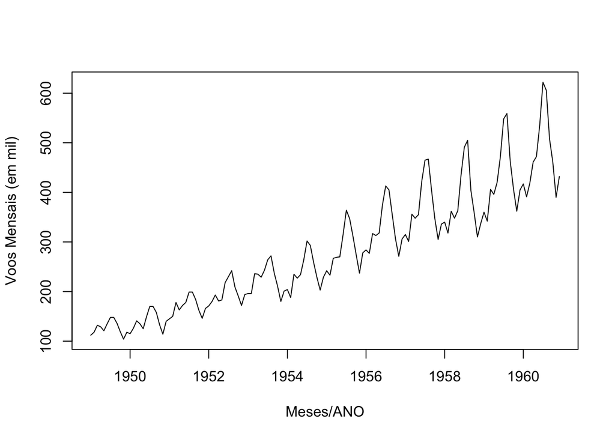

```r
ts.plot(AP,
        xlab ="Meses/ANO",
        ylab ="Voos Mensais (em mil)")
```

Nota-se que a série possui sazonalidade sistemática (multiplicativa) e tendência sistemática de crescimento. Portanto o método HW é mais adequado do que a previsão por suavização exponencial (média móvel ponderada), já que as previsões devem ser ajsutadas pelo parâmetro de tendência ($\beta$) e sazonalidade ($\gamma$).

Previsão pelo método HW:

```r
AP.hw <- HoltWinters(AP, seasonal = "mult")
AP.hw   # SSE - sum of squared errors
```

```
## Holt-Winters exponential smoothing with trend and multiplicative seasonal component.
##
## Call:
## HoltWinters(x = AP, seasonal = "mult")
##
## Smoothing parameters:
##  alpha: 0.2755925
##  beta : 0.03269295
##  gamma: 0.8707292
##
## Coefficients:
##            [,1]
## a   469.3232206
## b     3.0215391
## s1    0.9464611
## s2    0.8829239
## s3    0.9717369
## s4    1.0304825
## s5    1.0476884
## s6    1.1805272
## s7    1.3590778
## s8    1.3331706
## s9    1.1083381
## s10   0.9868813
## s11   0.8361333
## s12   0.9209877
```

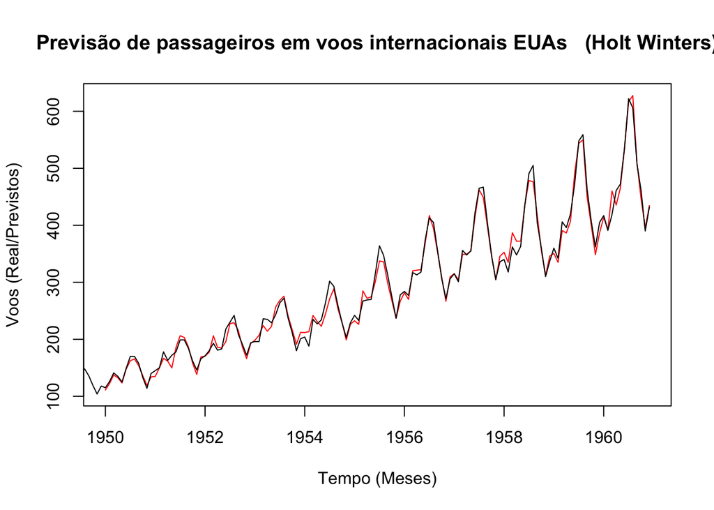

```r
plot(AP.hw,
     xlab = "Tempo (Meses)",
     ylab = "Voos (Real/Previstos)",
     main = "Previsão de passageiros em voos internacionais EUAs   (Holt Winters)")
```

A aplicação do método HW parece bastante assertiva, de forma que assumindo a continuidade dos padrões observados de sazonalidade, tendência e nível, podemos utilizá-lo para previsões em $t+k$ ( extrapolação).

2. Faça uma previsão para os próximos 4 anos utilizando o método Holt e Winters.

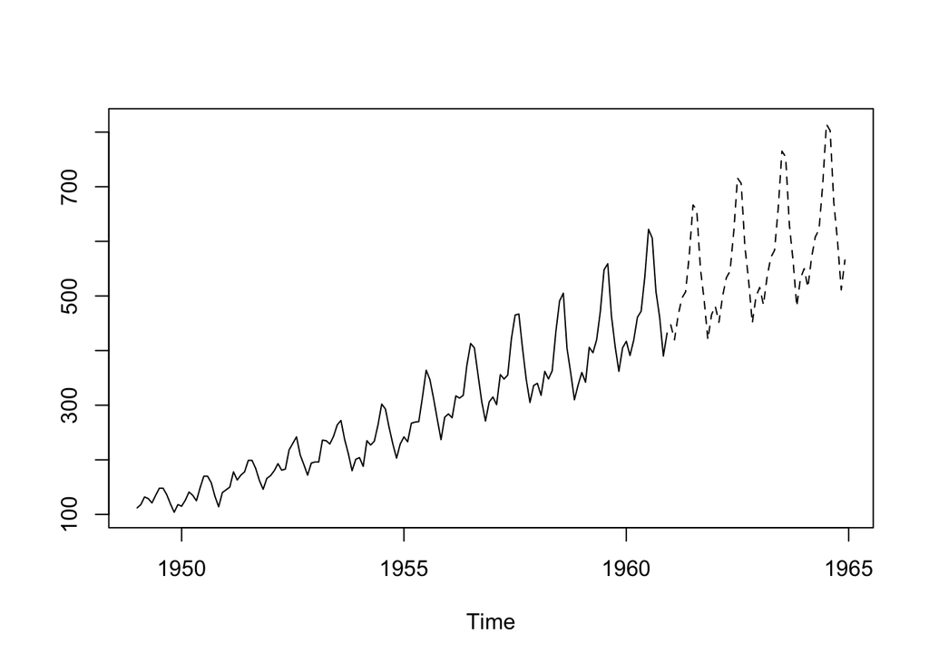

```r
AP.hw_predict <- predict(AP.hw, n.ahead = 4*12)
ts.plot(AP, AP.hw_predict, lty = 1:2) # lyt line type, foi pedido os estilos de 1 a 2
```

```r
AP.hw_predict
```

```
##           Jan      Feb      Mar      Apr      May      Jun      Jul      Aug
## 1961 447.0559 419.7123 464.8671 496.0839 507.5326 575.4509 666.5923 657.9137
## 1962 481.3732 451.7258 500.1008 533.4477 545.5202 618.2550 715.8704 706.2524
## 1963 515.6904 483.7392 535.3345 570.8114 583.5078 661.0591 765.1485 754.5912
## 1964 550.0076 515.7527 570.5682 608.1751 621.4954 703.8632 814.4265 802.9299
##           Sep      Oct      Nov      Dec
## 1961 550.3088 492.9853 420.2073 465.6345
## 1962 590.4954 528.7681 450.5242 499.0281
## 1963 630.6820 564.5509 480.8411 532.4217
## 1964 670.8687 600.3337 511.1580 565.8153
```

A previsão, seguindo os padrões de nível, tendência e sazonalidade, indicam a continuidade do crescimento do número de passageiros, e a sazonalidade multiplicativa. Os valores de previsão permitem, por exemplo, estimar algumas taxas de crescimento. Por exemplo, em que em janeiro de 1960, o número de passageiros foi 417 mil. Prevê-se que em janeiro de 1961, o número de passageiros deve ser de 447 mil. Portanto, um crescimento de 7,2% em um ano.

3. Discuta quais premissas garantiriam que a previsão efetuada é uma boa previsão.

Para este tipo de extrapolação, os parâmetros de nível ($\alpha$), tendência ($\beta$) e sazonalidade ($\gamma$) mantêm o mesmo padrão de comportamento no tempo.

4. Qual dos 2 tipos de abordagem discutidas na introdução do Tópico 3 foi usada nesta previsão?

Utilizamos a extrapolação, ou seja, a utilização do passado para prever o futuro em uma mesma série ( o padrão alternativo seria usar variáveis leading, com correlação cruzada). Mais especificamente utilizamos o método Holt Winters que é uma suavização exponencial com parâmetros de ajuste para tendência e sazonalidade sistemáticas.